# A computational model for antibiotic resistance

Jaelle Häfliger and Julia Eggenschwiler

2025-12-01

## Simulating evolutionary rescue in discrete time

In this notebook, we are implementing simulations of evolutionary rescue with 4 different mutations of different strengths in discrete time, as discussed and analyzed in the work by Orr & Unckless. The model is as follows: a haploid population starts with a given number of weak deleterious mutants and strong deleterious mutants. The model allows for mutation within one strain from deleterious to beneficial mutants, but also from beneficial to deleterious mutants (back-mutation). Of course in the first generation, only mutation from deleterious to beneficial is possible, since we start with 0 beneficial mutants of either strength.We define the two weak mutants as the weak strain and the two strong mutants as strong strain. We want to determine the trade-off of either starting only as weak deleterious and mutating to only weak beneficial or starting strong deleterious but being able to mutate to strong beneficial. To this scenario the back-mutation acts as an additional source of complexity. Each strain is considered rescued if the population-size of the stain stays bigger than 0 after max_gen (1000 generations).

## List of variables and parameters

- **N_end_wd:** size of the mutant (wd) population
- **N_end_wb:** size of the mutant (wb) population
- **N_end_sd:** size of the mutant (sd) population
- **N_end_sb:** size of the mutant (sb) population
- **init_wd:** initial population size of population with the weak deleterious mutation (should be a positive integer)
- **init_wb:** initial population size of the population with the weak beneficial mutation (should be a non-negative integer)
- **init_sd:** initial population size of the population with the strong deleterious mutation (should be a positive integer)
- **init_sb:** initial population size of the population with the strong beneficial mutation (should be a non-negative integer)
- **decay_rate_wm:** detrimental effect of the environment on the weak mutation (i.e., the populations carrying weak mutations decays at this rate; should be >0 to induce potential extinction)
- **decay_rate_sm:** detrimental effect of the environment on the strong mutation (i.e., the populations carrying strong mutations decays at this rate; should be >0 to induce potential extinction)
- **s_wm:** selective strength of the weak mutation (should be >decay_rate to allow for evolutionary rescue)
- **s_sm:** selective strength of the strong mutation (should be >decay_rate to allow for evolutionary rescue)
- **m_rate_wm:** mutation rate from the weak deletrious to the weak beneficial deleterious mutation and from weak beneficial to weak deleterious mutation (should be >0 and small)

  **m_rate_sm:** mutation rate from the strong deleterious to the strong beneficial mutation and from strong beneficial to strong deleterious mutation (should be >0 and small)
- **max_gen:** number of generations after which to stop the simulation (should be an integer >0; this is not a model parameter but a setting for the simulations). In the code presented here, the simulation stops automatically if the population goes extinct, or if it recovers and exceeds 10 times the original total population size, so **max_gen** can be set to a large value without creating extremely long simulation times.

## Our research-question:

How do 2 bacterial strains, which can alternate between beneficial and deleterious versions of the same strength via mutation and back-mutation, influence the probability of rescue and how does their frequency in the population change?

## Definitions

- wd: weak deleterious
- wb: weak beneficial
- sd: strong deleterious
- sb: strong beneficial

## Information about AI-usage:

We used ChatGPT to help with some aspects of the code-structure. Mainly to help with formatting the different plots. We manually verified the outcomes of the plots and the outputs generated by our simulations. Furthermore, for difficult coding parts, we used ChatGPT to give as a broad idea of an approach, which we could then apply and change so that it fits our model. All descriptions and annotations were produced without any AI tools.

```r
# Function for simulating one generation in the Population
# adding the population sizes, decay rates, selection coefficients and mutation rates
simulate_one_gen <- function(N_wd, N_wb, N_sd, N_sb, decay_rate_wm, decay_rate_sm, s_wm, s_sm, m_rate_wm, m_rate_sm) {

  # draw Offspring according to Poisson Distribution
  # altered so all four different mutations are considered
  # for deleterious mutations the s is calculated minus (negative effect) and for the beneficial mutation the s is added (positive effect)

  offsp_wd <- rpois(1, N_wd * (1-decay_rate_wm-s_wm))
  offsp_wb <- rpois(1, N_wb * (1-decay_rate_wm+s_wm))
  offsp_sd <- rpois(1, N_sd * (1-decay_rate_sm-s_sm))
  offsp_sb <- rpois(1, N_sb * (1-decay_rate_sm+s_sm))

  # draw changing Mutants according to Poisson Distribution
  # alterations considering the for different mutations

  mut_wd_to_wb <- rpois(1, offsp_wd * m_rate_wm)
  mut_sd_to_sb <- rpois(1, offsp_sd * m_rate_sm)
  mut_wb_to_wd <- rpois(1, offsp_wb * m_rate_wm)
  mut_sb_to_sd <- rpois(1, offsp_sb * m_rate_sm)

  # determine new Population Sizes of all four Mutants (2 versions of weak Mutations   and 2   versions of strong Mutations)
  # to account for back mutations as well (beneficial to deleterious), mutations rates for these cases are added (mut_b_to_d)

  N_wd_new <- max(offsp_wd - mut_wd_to_wb+ mut_wb_to_wd,0)
  N_wb_new <- max(offsp_wb - mut_wb_to_wd+ mut_wd_to_wb,0)
  N_sd_new <- max(offsp_sd - mut_sd_to_sb+ mut_sb_to_sd,0)
  N_sb_new <- max(offsp_sb - mut_sb_to_sd+ mut_sd_to_sb,0)

  # with the return function, the new values for population sizes are stored

   # Return new population sizes and mutation changes
  return(list(
    N_wd_new = N_wd_new,
    N_wb_new = N_wb_new,
    N_sd_new = N_sd_new,
    N_sb_new = N_sb_new,
    mut_wb_to_wd = mut_wb_to_wd,
    mut_wd_to_wb = mut_wd_to_wb,
    mut_sb_to_sd = mut_sb_to_sd,
    mut_sd_to_sb = mut_sd_to_sb
  ))
}
  # with print we visualize the numbers we get for the population sizes and mutation changes, we simulate the population by setting our parameters to certain values


print(simulate_one_gen(N_wd=30, N_wb=0, N_sd=30, N_sb=0, decay_rate_wm=0.05, decay_rate_sm=0.1, s_wm=0.1, s_sm=0.2, m_rate_wm=0.05, m_rate_sm=0.07))
```

```
## $N_wd_new
## [1] 30
##
## $N_wb_new
## [1] 0
##
## $N_sd_new
## [1] 25
##
## $N_sb_new
## [1] 3
##
## $mut_wb_to_wd
## [1] 0
##
## $mut_wd_to_wb
## [1] 0
##
## $mut_sb_to_sd
## [1] 0
##
## $mut_sd_to_sb
## [1] 3
```

## Simulate a population trajectory

```r
# Simulation runs until the 1000th Generation

max_gen=1000

#With this function we simulate over generations, we put initial population sizes of the four mutations, with the parameter max_gen we determine that our simulation maximally runs until the 1000th generation

simulate_pop <- function(init_wd, init_wb,  init_sd, init_sb, decay_rate_wm, decay_rate_sm, s_wm, s_sm, m_rate_wm, m_rate_sm, max_gen) {

  # Create the Vector in which to save the Results
  pop_vector <- c(init_wd,init_wb, init_sd, init_sb)

  # initiate the variables
  pop_new <- c(init_wd, init_wb, init_sd, init_sb)

  # defining counters for mutation changes
  count_wb_to_wd <- 0
  count_wd_to_wb <- 0
  count_sb_to_sd <- 0
  count_sd_to_sb <- 0
  total_mut_events <- 0

  # run the Simulation until Generation max_gen
  for (i in 1:(max_gen + 1)) {

    # redefine the current Population one Generation later
    results <- simulate_one_gen(pop_new[1],pop_new[2],pop_new[3],pop_new[4], decay_rate_wm, decay_rate_sm, s_wm, s_sm, m_rate_wm, m_rate_sm)

    # add the new Population Sizes to the Output Vector
    pop_new <- c(results$N_wd_new, results$N_wb_new, results$N_sd_new, results$N_sb_new)
    pop_vector <- rbind(pop_vector,pop_new)

     # count for tracking Mutations
    count_wb_to_wd <- count_wb_to_wd + results$mut_wb_to_wd
    count_wd_to_wb <- count_wd_to_wb + results$mut_wd_to_wb
    count_sb_to_sd <- count_sb_to_sd + results$mut_sb_to_sd
    count_sd_to_sb <- count_sd_to_sb + results$mut_sd_to_sb
    total_mut_events <- total_mut_events + results$mut_wb_to_wd + results$mut_wd_to_wb +
      results$mut_sb_to_sd + results$mut_sd_to_sb

    # Condition to stop the Simulation before max_gen: either the Population exceeds 10 Times the Original Population Size, or it goes extinct

    if ((sum(pop_new) >= 10 * sum(c(init_wd, init_wb, init_sd, init_sb))) || sum(pop_new) == 0)
      break

}
    # calculating Mutation Frequencies percent
    if (total_mut_events > 0) {
    freq_wb_to_wd <- 100 * count_wb_to_wd / total_mut_events
    freq_wd_to_wb <- 100 * count_wd_to_wb / total_mut_events
    freq_sb_to_sd <- 100 * count_sb_to_sd / total_mut_events
    freq_sd_to_sb <- 100 * count_sd_to_sb / total_mut_events
  } else {
    freq_wb_to_wd <- freq_wd_to_wb <- freq_sb_to_sd <- freq_sd_to_sb <- 0
  }
  # Define the Row and Column Names of the Output Vector
  rownames(pop_vector) <- (0:max_gen)[1:length(pop_vector[,1])]

  # the colom-names in our vectors are according to our mutations (wd, wb, sd, sb)

  colnames(pop_vector) <- c("wd","wb", "sd", "sb")



  # Return mutation results
  return(list(
    population = pop_vector,
    switch_stats = data.frame(
      wb_to_wd = freq_wb_to_wd,
      wd_to_wb = freq_wd_to_wb,
      sb_to_sd = freq_sb_to_sd,
      sd_to_sb = freq_sd_to_sb
    )
  ))
}




# Test the Function and plot the Result

max_gen <- 100

# Simulation Data with certain values determined

output <- simulate_pop(init_wd=30, init_wb=0,  init_sd=30, init_sb=0, decay_rate_wm=0.05, decay_rate_sm=0.1, s_wm=0.1, s_sm=0.2, m_rate_wm=0.05, m_rate_sm=0.07,max_gen)

# show the last few Lines of the Data Table

print(tail(output))
```

```
## $population
##      wd wb sd sb
## 0    30  0 30  0
## 1    22  0 12  6
## 2    21  1 10  9
## 3    16  3  9  9
## 4    12  6  5 14
## 5    12  8  1 12
## 6    14  7  3 14
## 7    12  5  2 23
## 8    13 10  2 21
## 9     3 11  3 16
## 10    1 15  3 19
## 11    1 14  3 22
## 12    2 18  3 27
```

[output cut: 93 more lines]

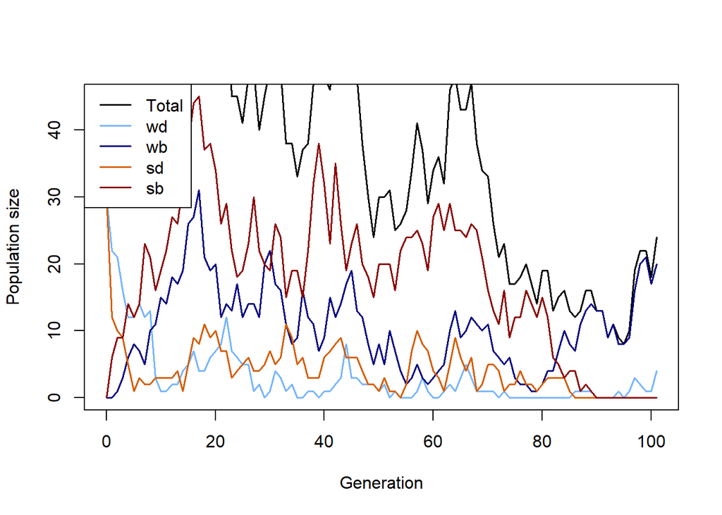

```r
# extracting Population-Matrix
pop_matrix <- output$population

# assign frequencies of mutation changes
switch_stats <- output$switch_stats


# determine x Axis Range
x_range <- 0:(nrow(pop_matrix)-1)

# plot the Output
# this plots the total Population Size-black line visible in the plot
plot(x_range, pop_matrix[,1] + pop_matrix[,2] + pop_matrix[,3] + pop_matrix[,4],
     type='l', ylim=c(0,max(pop_matrix)), xlab="Generation", ylab="Population size",
     col="black", lwd=1.5)

# adding each mutant
lines(x_range, pop_matrix[,1], col="#77b5fe", lwd=1.5) # wd
lines(x_range, pop_matrix[,2], col="navyblue", lwd=1.5) # wb
lines(x_range, pop_matrix[,3], col="#D55E00", lwd=1.5) # sd
lines(x_range, pop_matrix[,4], col="darkred", lwd=1.5) # sb

# Legend
legend("topleft",
       legend=c("Total","wd","wb","sd","sb"),
       col=c("black","#77b5fe","navyblue","#D55E00","darkred"),
       lty=1, lwd=1.5)
```

```r
# output of mutation changes in per cent
print(switch_stats)
```

```
##   wb_to_wd wd_to_wb sb_to_sd sd_to_sb
## 1 21.81818        5 62.72727 10.45455
```

Plot, which shows the outcome of our simulations over maximum 1000 generations. But the whole population (all four mutants together) is visualized, to see what the overall dynamics of our simulations are. Furthermore, this plots are helpful because our model tends to be strongly stochastic. So this part can easily be re-run to get a better understanding of this behaviour.

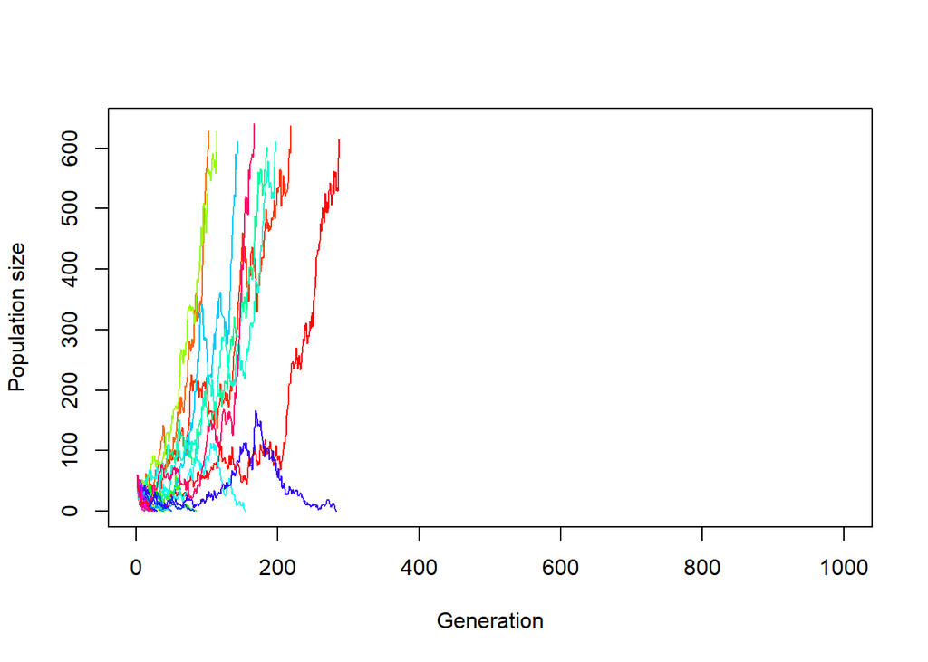

```r
# code for plotting the result of different populations in one plot
init_wd <- 30
init_wb <- 0
init_sd <- 30
init_sb <- 0
m_rate_wm <- 0.05
m_rate_sm <- 0.07
decay_rate_wm <- 0.05
decay_rate_sm <- 0.1
s_wm <- 0.1
s_sm <- 0.2
max_gen <- 1000
replicates <- 30


# defining Data Frame to save one Row (Population Size for multiple Generations until max_gen) after one Loop
temp_output <- data.frame(array(NA, dim = c(0,max_gen)))
# defining Data Frame to save all Results from Loop
final_output <- data.frame(array(NA, dim = c(replicates,max_gen)))
# defining a Set of colors in order to color each Line differently
lines_colors <- rainbow(replicates)

# simulating a population multiple times
for (i in 1:replicates) {
  temp_output <- simulate_pop(
    init_wd, init_wb, init_sd, init_sb,
    decay_rate_wm, decay_rate_sm,
    s_wm, s_sm,
    m_rate_wm, m_rate_sm,
    max_gen = max_gen)
  # extract Pop Matrix
  pop_matrix <- temp_output$population

  # calculate Row Sums
  temp_output <- rowSums(pop_matrix[, c("wd", "wb", "sd", "sb")])
  # adding to Result Table
  final_output[i, 1:length(temp_output)]<-temp_output
}

# defining end_gen which is as long as the last Generation where the pop size is an actual Number and not NA yet
end_gen<-tail(which(!is.na(final_output[1,])), 1)
# Plot first Line / first Population
plot(x=1:max_gen,y=final_output[1,1:max_gen],type='l',ylim=c(0,max(final_output, na.rm = TRUE)),xlab =  "Generation",ylab = "Population size", col = lines_colors[1])
# Loop for plotting each Row of Data Table / Population as a Line in the Plot
for (i in 1:replicates) {

  end_gen<-tail(which(!is.na(final_output[i,])), 1)
  # each line gets assigned to a Color of lines_colors
  lines(x=1:max_gen,y=final_output[i,1:max_gen], col=lines_colors[i])


}
```

## Mutant frequencies and rescue probability per mutant

In this piece of code, we calculate the rescue probability of each mutant separately and visualize this using different plots. Furthermore, we calculate the frequency of each mutant (wd, wb, sd, sb) after 1000 generations. The purpose of these plots is mainly to show the effect of each mutation on a population and how the frequencies differ, which helps provide an overview and hopefully provides better understanding of the quite complex dynamics.

```r
# set some Parameters to fixed Values

init_wd <- 30
init_wb <- 0
init_sd <- 30
init_sb <- 0
m_rate_wm <- 0.05
m_rate_sm <- 0.07
decay_rate_wm <- 0.05
decay_rate_sm <- 0.1
s_wm <- 0.1
s_sm <- 0.2
max_gen <- 1000
# determine how often to run the Simulation for each set of Parameters
no_replicates <- 50


# set Parameters to vary
s_values_wm <- c(0.10,0.15,0.2)
s_values_sm <- c(0.25,0.30,0.35)
#Commented to vary always only one variable
#m_values_wm <- c(0.001,0.01,0.05)
#m_values_sm <- c(0.05,0.1,0.15)


# initialize Data Table - where to collect the Results
data_table <- c()
data_table_wd<- c()
data_table_wb<- c()
data_table_sd<- c()
data_table_sb<- c()
# empty list to save rescue results
rescue_results <- data.frame(
  s_wm = numeric(),
  s_sm = numeric(),
  replicate = integer(),
  rescued = integer()
)

# preparing list to save mutation changes (in per cent) for all replicates - only if they exist
switch_stats_all <- data.frame(
  s_wm = numeric(),
  s_sm = numeric(),
  replicate = integer(),
  wb_to_wd = numeric(),
  wd_to_wb = numeric(),
  sb_to_sd = numeric(),
  sd_to_sb = numeric()
)

library(dplyr)
```

```r
library(ggplot2)
library(tidyr)
# define total runs and rescue count
total_runs<-0
rescue_count<-0
# run the Simulation across all chosen parameters
# loop over mutation rates
#for(mval_wm in m_values_wm){
 # for(mval_sm in m_values_sm){
    # loop over Selection strength
    for(sval_wm in s_values_wm){
      for(sval_sm in s_values_sm){
        # different Way of running many Simulations: make Replicates using "repeat" Function         with a counter i
        # reset Counter
        i<-1

        repeat {
          # increase Counter by one
          i<-i+1
          # defining total runs
          total_runs <- total_runs + 1
          # run the Simulation once
          one_run <- simulate_pop(init_wd, init_wb, init_sd, init_sb,
                                  decay_rate_wm, decay_rate_sm,
                                  sval_wm, sval_sm, m_rate_wm,m_rate_sm, max_gen)

          # determine total Population Sizes
         pop_matrix <- one_run$population

         total_size <- rowSums(pop_matrix)

  # defining popuation matrix
  pop_matrix <- one_run$population
  # calculating total size (1 row is equal to total pop size, meaning adding up all columns)
  total_size <- rowSums(pop_matrix)
# saving mutation changes
 if (!is.null(one_run$switch_stats) && nrow(one_run$switch_stats) > 0) {
  switch_stats <- one_run$switch_stats
  switch_stats_all <- rbind(
    switch_stats_all,
    data.frame(
      s_wm = sval_wm,
      s_sm = sval_sm,
      replicate = i-1,
      wb_to_wd = switch_stats$wb_to_wd,
      wd_to_wb = switch_stats$wd_to_wb,
      sb_to_sd = switch_stats$sb_to_sd,
      sd_to_sb = switch_stats$sd_to_sb
    )
  )
}


          # determine final Population Size for each Mutant
          N_end_wd <- pop_matrix[nrow(pop_matrix), "wd"]
          N_end_wb <- pop_matrix[nrow(pop_matrix), "wb"]
          N_end_sd <- pop_matrix[nrow(pop_matrix), "sd"]
          N_end_sb <- pop_matrix[nrow(pop_matrix), "sb"]

          total_end <- N_end_wd + N_end_wb + N_end_sd + N_end_sb
          # introduce rescue count
         rescued_wd <- ifelse(N_end_wd > 0, 1, 0)
         rescued_wb <- ifelse(N_end_wb > 0, 1, 0)
         rescued_sd <- ifelse(N_end_sd > 0, 1, 0)
         rescued_sb <- ifelse(N_end_sb > 0, 1, 0)


          # save rescue outcome (rescue or extinction)
          rescue_results <- rbind(rescue_results,
            data.frame(
              s_wm = sval_wm,
              s_sm = sval_sm,
              replicate = i - 1,
              rescued_wd = rescued_wd,
              rescued_wb = rescued_wb,
              rescued_sd = rescued_sd,
              rescued_sb = rescued_sb
  )
)

          # determine Frequencies of each mutant in the final Population
          freq_wd <- ifelse(total_end > 0, N_end_wd / total_end, 0)
          freq_wb <- ifelse(total_end > 0, N_end_wb / total_end, 0)
          freq_sd <- ifelse(total_end > 0, N_end_sd / total_end, 0)
          freq_sb <- ifelse(total_end > 0, N_end_sb / total_end, 0)



          data_table_wd<- rbind(data_table_wd, c(sval_wm,freq_wd))
          data_table_wb<- rbind(data_table_wb, c(sval_wm, freq_wb))
          data_table_sd<- rbind(data_table_sd,c(sval_sm, freq_sd))
          data_table_sb<-rbind(data_table_sb, c (sval_sm,freq_sb))
          # enter the Data into the Table
          data_table <- rbind(data_table,c(m_rate_wm = 0.001,m_rate_sm = 0.005,sval_wm,sval_sm,N_end_wd,N_end_wb, N_end_sd, N_end_sb,freq_wd, freq_wb, freq_sd,freq_sb)) # note that we add the varying Parameters (Mutation Rate and Selection Strength for each Version of weak and strong Mutation) to the Table too
          # stop the repeated Computation after no_replicates times


          if(i>no_replicates) break

        }
      }
    }
  #}
#}

# Population over generations
print(one_run$population)
```

```
##    wd wb sd  sb
## 0  30  0 30   0
## 1  21  0 16   2
## 2  18  1 10   4
## 3  10  2  3   4
## 4   7  5  4   4
## 5   5  3  2   4
## 6   3  2  2   5
## 7   4  1  0   4
## 8   2  4  1   8
## 9   0  1  0  11
## 10  0  1  1  18
## 11  0  1  2  21
## 12  0  0  2  27
## 13  0  0  4  30
```

[output cut: 25 more lines]

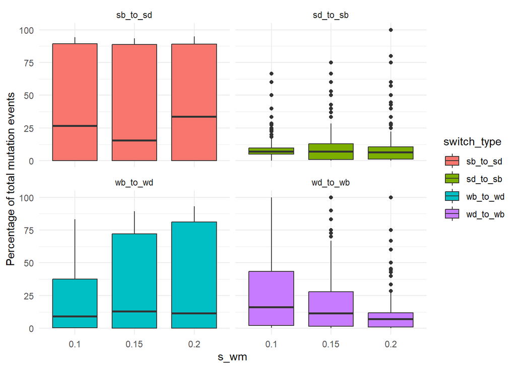

```r
# Mutation changes in percent

#important note!:
#switch_stats_all was really helpful to us to observe the mutation dynamcis of the whole population and of the two strains and we think it really helps to understand our model better. However, we put the command: "print(switch_stats_all)" into comments, because it would take up too much space in the html-document.

#print(switch_stats_all)



# Make sure data is a proper data frame
data_table_wd <- as.data.frame(data_table_wd)

# If the column names are missing or wrong, set them
colnames(data_table_wd) <- c("V1", "V2")

# Add an Index Column for plotting along x-axis
data_table_wd$Index <- 1:nrow(data_table_wd)

# plotting Mutation Changes with different s values
switch_long <- switch_stats_all %>%
  pivot_longer(cols = c(wb_to_wd, wd_to_wb, sb_to_sd, sd_to_sb),
               names_to = "switch_type",
               values_to = "percent")

ggplot(switch_long, aes(x = factor(s_wm), y = percent, fill = switch_type)) +
  geom_boxplot() +
  facet_wrap(~ switch_type) +
  labs(x = "s_wm", y = "Percentage of total mutation events") +
  theme_minimal()
```

```r
# calculate Rescue Probability per Parameter Combination

rescue_summary <- rescue_results %>%
  group_by(s_wm, s_sm) %>%
  summarise(
    rescue_prob_wd = mean(rescued_wd),
    rescue_prob_wb = mean(rescued_wb),
    rescue_prob_sd = mean(rescued_sd),
    rescue_prob_sb = mean(rescued_sb),
    .groups = "drop"
  )

print(rescue_summary)
```

```
## # A tibble: 9 × 6
##    s_wm  s_sm rescue_prob_wd rescue_prob_wb rescue_prob_sd rescue_prob_sb
##   <dbl> <dbl>          <dbl>          <dbl>          <dbl>          <dbl>
## 1  0.1   0.25           0.16           0.2            0.36           0.36
## 2  0.1   0.3            0.22           0.24           0.6            0.6
## 3  0.1   0.35           0.16           0.16           0.46           0.46
## 4  0.15  0.25           0.36           0.36           0.42           0.42
## 5  0.15  0.3            0.42           0.44           0.4            0.4
## 6  0.15  0.35           0.28           0.28           0.38           0.38
## 7  0.2   0.25           0.44           0.44           0.42           0.42
## 8  0.2   0.3            0.36           0.4            0.54           0.54
## 9  0.2   0.35           0.52           0.52           0.56           0.56
```

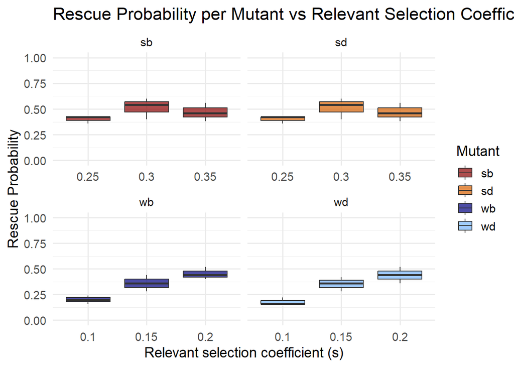

```r
# Prepare rescue data
rescue_long <- rescue_summary %>%
  pivot_longer(
    cols = starts_with("rescue_prob_"),
    names_to = "mutant",
    values_to = "rescue_prob"
  ) %>%
  mutate(
    mutant = gsub("rescue_prob_", "", mutant),
    s_value = case_when(
      mutant %in% c("wd", "wb") ~ s_wm,
      mutant %in% c("sd", "sb") ~ s_sm
    )
  )

# Plotting Rescue Probability with different s values
library(ggplot2)

ggplot(rescue_long, aes(x = factor(s_value), y = rescue_prob, fill = mutant)) +
  geom_boxplot(alpha = 0.7) +
  scale_y_continuous(limits = c(0, 1)) +
  scale_fill_manual(values = c(
    "wd" = "#77b5fe",
    "wb" = "navyblue",
    "sd" = "#D55E00",
    "sb" = "darkred"
  )) +
  facet_wrap(~ mutant, scales = "free_x") +
  labs(
    title = "Rescue Probability per Mutant vs Relevant Selection Coefficient (Boxplot)",
    x = "Relevant selection coefficient (s)",
    y = "Rescue Probability",
    fill = "Mutant"
  ) +
  theme_minimal(base_size = 14)
```

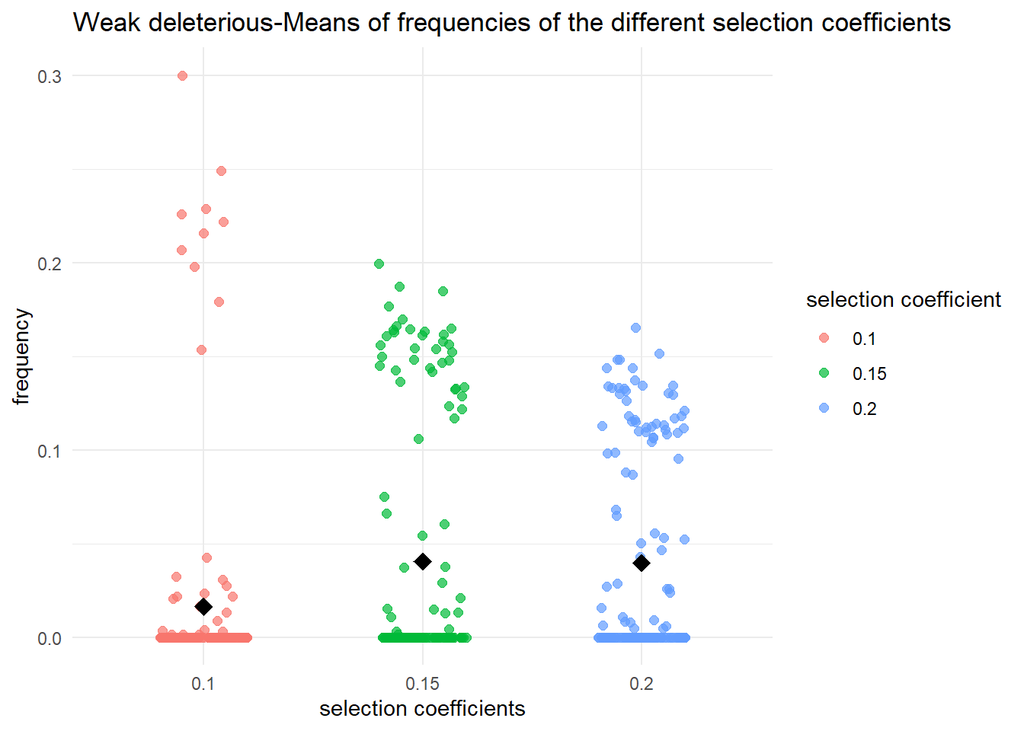

```r
# plotting wd with different s values
  # making sure that its a data frame
data_table_wd <- as.data.frame(data_table_wd)
colnames(data_table_wd) <- c("V1", "V2")


  # Scatterplot of wd with jitter and mean
library(ggplot2)
ggplot(data_table_wd, aes(x = factor(V1), y = V2, color = factor(V1))) +
  geom_jitter(width = 0.2, height = 0, size = 2, alpha = 0.7) +
  stat_summary(fun = mean, geom = "point", shape = 18, size = 4, color = "black") +
  labs(
    x = "selection coefficients",
    y = "frequency",
    color = "selection coefficient",
    title = "Weak deleterious-Means of frequencies of the different selection coefficients"
  ) +
  theme_minimal()
```

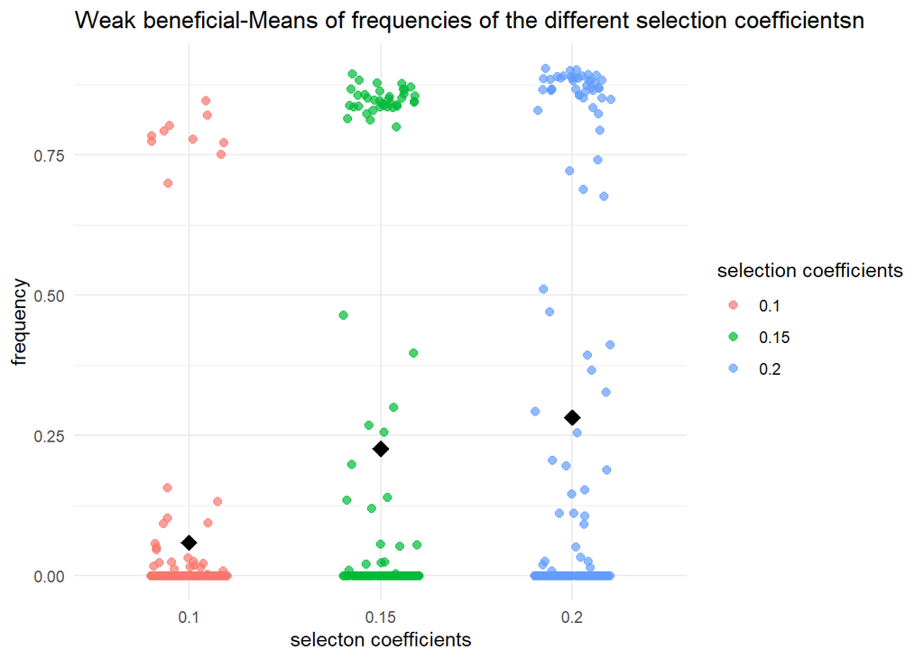

```r
# plotting wb with different s values
  # making sure that its a data frame
data_table_wb <- as.data.frame(data_table_wb)
colnames(data_table_sb) <- c("V1", "V2")

# Scatterplot of wb with jitter and mean
ggplot(data_table_wb, aes(x = factor(V1), y = V2, color = factor(V1))) +
  geom_jitter(width = 0.2, height = 0, size = 2, alpha = 0.7) +
  stat_summary(fun = mean, geom = "point", shape = 18, size = 4, color = "black") +
  labs(
    x = "selecton coefficients",
    y = "frequency",
    color = "selection coefficients",
    title = "Weak beneficial-Means of frequencies of the different selection coefficientsn"
  ) +
  theme_minimal()
```

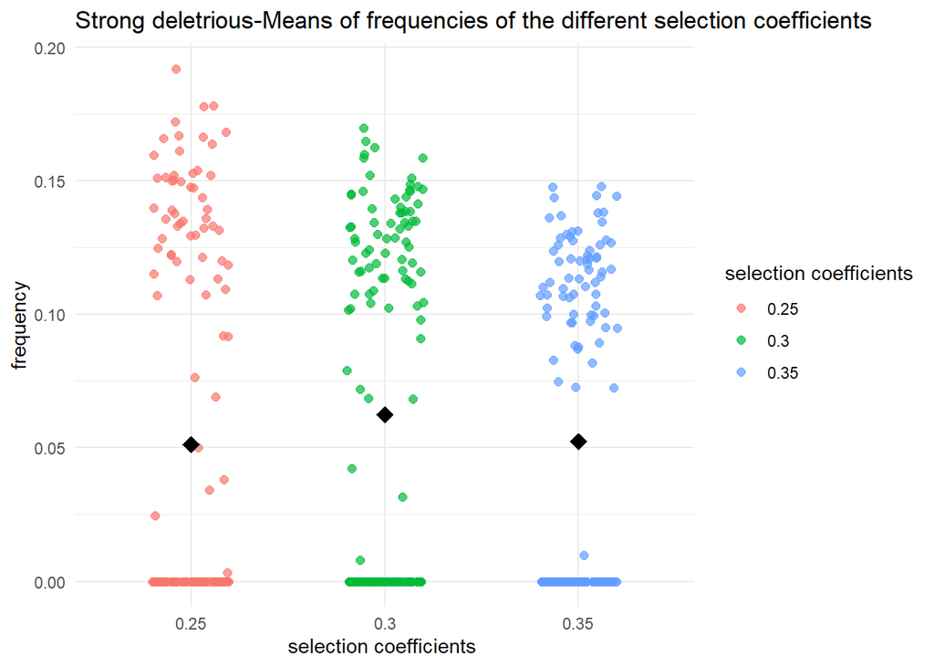

```r
# plotting sd with different s values
  # making sure that its a data frame
data_table_sd <- as.data.frame(data_table_sd)

colnames(data_table_sd) <- c("V1", "V2")

  # Scatterplot of sd with jitter and mean
ggplot(data_table_sd, aes(x = factor(V1), y = V2, color = factor(V1))) +
  geom_jitter(width = 0.2, height = 0, size = 2, alpha = 0.7) +
  stat_summary(fun = mean, geom = "point", shape = 18, size = 4, color = "black") +
  labs(
    x = "selection coefficients ",
    y = "frequency",
    color = "selection coefficients",
    title = "Strong deletrious-Means of frequencies of the different selection coefficients"
  ) +
  theme_minimal()
```

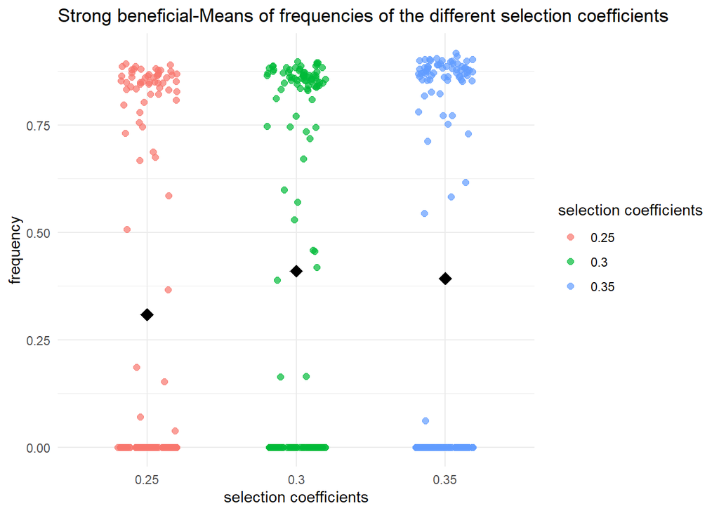

```r
# plotting sb with different s values
  # making sure that its a data frame
data_table_sb <- as.data.frame(data_table_sb)
colnames(data_table_sb) <- c("V1", "V2")

  # Scatterplot of sb with jitter and mean
ggplot(data_table_sb, aes(x = factor(V1), y = V2, color = factor(V1))) +
  geom_jitter(width = 0.2, height = 0, size = 2, alpha = 0.7) +
  stat_summary(fun = mean, geom = "point", shape = 18, size = 4, color = "black") +
  labs(
    x = "selection coefficients",
    y = "frequency",
    color = "selection coefficients",
    title = "Strong beneficial-Means of frequencies of the different selection coefficients"
  ) +
  theme_minimal()
```

```r
# mean Frequencies of each mutant
mean_freq_wd <- mean(freq_wd)*100
mean_freq_wb <- mean(freq_wb)*100
mean_freq_sd <- mean(freq_sd)*100
mean_freq_sb <- mean(freq_sb)*100

print(paste("Mean frequency of wd =", mean_freq_wd) )
```

```
## [1] "Mean frequency of wd = 0"
```

```r
print(paste("Mean frequency of wb =", mean_freq_wb) )
```

```
## [1] "Mean frequency of wb = 0"
```

```r
print(paste("Mean frequency of sd =", mean_freq_sd) )
```

```
## [1] "Mean frequency of sd = 9.67741935483871"
```

```r
print(paste("Mean frequency of sb =", mean_freq_sb) )
```

```
## [1] "Mean frequency of sb = 90.3225806451613"
```

```r
# define Column Names of Data Table
colnames(data_table) <- c("m_rate_wm","m_rate_sm","s_wm","s_sm","N_end_wd", "N_end_wb", "N_end_sd", "N_end_sb","freq_wd", "freq_wb", "freq_sd","freq_sb")
# show the first and last Lines of the Output
print(head(data_table))
```

```
##      m_rate_wm m_rate_sm s_wm s_sm N_end_wd N_end_wb N_end_sd N_end_sb freq_wd
## [1,]     0.001     0.005  0.1 0.25        0        0        0        0       0
## [2,]     0.001     0.005  0.1 0.25        0        0        0        0       0
## [3,]     0.001     0.005  0.1 0.25        0        0        0        0       0
## [4,]     0.001     0.005  0.1 0.25        0        0        0        0       0
## [5,]     0.001     0.005  0.1 0.25        0        0        0        0       0
## [6,]     0.001     0.005  0.1 0.25        0        0       91      525       0
##      freq_wb   freq_sd   freq_sb
## [1,]       0 0.0000000 0.0000000
## [2,]       0 0.0000000 0.0000000
## [3,]       0 0.0000000 0.0000000
## [4,]       0 0.0000000 0.0000000
## [5,]       0 0.0000000 0.0000000
## [6,]       0 0.1477273 0.8522727
```

```r
print(tail(data_table))
```

```
##        m_rate_wm m_rate_sm s_wm s_sm N_end_wd N_end_wb N_end_sd N_end_sb
## [445,]     0.001     0.005  0.2 0.35        0        0        0        0
## [446,]     0.001     0.005  0.2 0.35        0        0        0        0
## [447,]     0.001     0.005  0.2 0.35       79      527        0        0
## [448,]     0.001     0.005  0.2 0.35        0        0       62      555
## [449,]     0.001     0.005  0.2 0.35        0        0       93      580
## [450,]     0.001     0.005  0.2 0.35        0        0       66      616
##         freq_wd  freq_wb    freq_sd   freq_sb
## [445,] 0.000000 0.000000 0.00000000 0.0000000
## [446,] 0.000000 0.000000 0.00000000 0.0000000
## [447,] 0.130363 0.869637 0.00000000 0.0000000
## [448,] 0.000000 0.000000 0.10048622 0.8995138
## [449,] 0.000000 0.000000 0.13818722 0.8618128
## [450,] 0.000000 0.000000 0.09677419 0.9032258
```

Comparison of the overall rescue-probablity of the weak and strong bacterial strain to determine whether the trade-off pays off after 1000 generations.

This last piece of code, calculates the rescue-probability of the strong and the weak bacterial strain, with the according s_values and m_values. This result is then visualzed with one heatmap for each strain.

Furthermore, a barplot is used to show in how many cases the weak or strong bacterial strain “wins” and in how many cases total extinction occurs.

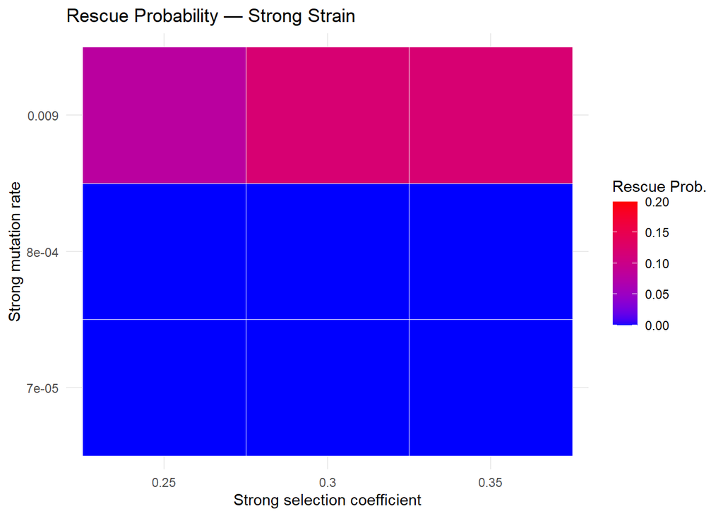

```r
#initial population-sizes of the deleterious mutations set to 30
init_wd <- 30
init_wb <- 0
init_sd <- 30
init_sb <- 0
#decay-rates set to fixed values
decay_rate_wm <- 0.05
decay_rate_sm <- 0.1
s_wm <- 0.1
s_sm <- 0.2

max_gen <- 1000
no_replicates <- 50

#selection coefficients s and mutation rates m, varied (3 different values for both the weak and the strong strain)
s_values_wm <- c(0.10, 0.15, 0.20)
s_values_sm <- c(0.25, 0.30, 0.35)
m_values_wm <- c(4e-5, 5e-4, 6e-3)
m_values_sm <- c(7e-5, 8e-4, 9e-3)



#----strong mutation----

#in this part we set up a data frame to store the rescue results for the strong mutation, which then includes the selection coefficients and mutation rates of the strong mutation, stored as numeric values and the number of rescues for the strong beneficial and strong deleterious mutations

rescue_results_strong <- data.frame(
  s_sm = numeric(),
  m_sm = numeric(),
  replicate = integer(),
  rescued_strong = integer()
)

#in a next step the m_values and s_values are varied (for both 3 different values as explained above), which is done for 50 replicates
for (mval in m_values_sm) {
  for (sval in s_values_sm) {
    for (rep in 1:no_replicates) {

      one_run <- simulate_pop(
        init_wd, init_wb, init_sd, init_sb,
        decay_rate_wm, decay_rate_sm,
        s_wm, sval, m_rate_wm, mval, max_gen
      )

      pop <- one_run$population
      N_sd = tail(pop[, "sd"], 1)
      N_sb = tail(pop[, "sb"], 1)

    #the strong strain is considered "alive" in our model, if the combined population-size of the strong beneficial and strong deleterious mutation is still bigger than 0

      strong_alive = as.integer((N_sd + N_sb) > 0)

  # in rescue_results_strong the paramters, selection coefficients and mutation rates are listed together with whether the population was rescued (1) or went extinct (0), this overview provides the results for each of the 50 replicates separate

      rescue_results_strong <- rbind(
        rescue_results_strong,
        data.frame(
          s_sm = sval,
          m_sm = mval,
          replicate = rep,
          rescued_strong = strong_alive
        )
      )
    }
  }
}

# in rescue_summary_strong the rescue-results are summarized, so that the probability is calculated for every combination of the mutation rates with the selection coefficients (equals to 3x3)

rescue_summary_strong <- rescue_results_strong %>%
  group_by(s_sm, m_sm) %>%
  summarise(rescue_prob_strong = mean(rescued_strong), .groups = "drop")

#----weak mutation----

#in this part we set up a data frame to store the rescue results for the weak mutation, which then includes the selection coefficients and mutation rates of the weak mutation, stored as numeric values and the number of rescues for the weak beneficial and weak deleterious mutations

rescue_results_weak <- data.frame(
  s_wm = numeric(),
  m_wm = numeric(),
  replicate = integer(),
  rescued_weak = integer()
)

#in a next step the m_values and s_values are varied (for both 3 different values as explained above), which is done for 50 replicates

for (mval in m_values_wm) {
  for (sval in s_values_wm) {
    for (rep in 1:no_replicates) {

      one_run <- simulate_pop(
        init_wd, init_wb, init_sd, init_sb,
        decay_rate_wm, decay_rate_sm,
        sval, s_sm, mval, m_rate_sm, max_gen
      )

      pop <- one_run$population
      N_wd = tail(pop[, "wd"], 1)
      N_wb = tail(pop[, "wb"], 1)


   #the weak strain is considered "alive" in our model, if the combined population-size of the weak beneficial and weak deleterious mutation is still bigger than 0

      weak_alive = as.integer((N_wd + N_wb) > 0)

    # in rescue_results_weak the parameters, selection coefficients and mutation rates are listed together with whether the population was rescued (1) or went extinct (0), this overview provides the results for each of the 50 replicates separately

      rescue_results_weak <- rbind(
        rescue_results_weak,
        data.frame(
          s_wm = sval,
          m_wm = mval,
          replicate = rep,
          rescued_weak = weak_alive
        )
      )
    }
  }
}

# in rescue_summary_weak the rescue-results are summarized, so that the probability is calculated for every combination of the mutation rates with the selection coefficients (equals to 3x3)

rescue_summary_weak <- rescue_results_weak %>%
  group_by(s_wm, m_wm) %>%
  summarise(rescue_prob_weak = mean(rescued_weak), .groups = "drop")

# with the function ggplot, we this section produces the heatmaps for both the weak and strong bacterial strain separately, blue colour indicating 0 rescue probability, red indicating the highest rescue probability (in our case up to approximately 0.20)

ggplot(rescue_summary_strong,
       aes(x = factor(s_sm), y = factor(m_sm), fill = rescue_prob_strong)) +
  geom_tile(color = "white") +
  scale_fill_gradient(low = "blue", high = "red", limits = c(0, 0.2), oob = scales::squish) +
  labs(title = "Rescue Probability — Strong Strain",
       x = "Strong selection coefficient",
       y = "Strong mutation rate",
       fill = "Rescue Prob.") +
  theme_minimal()
```

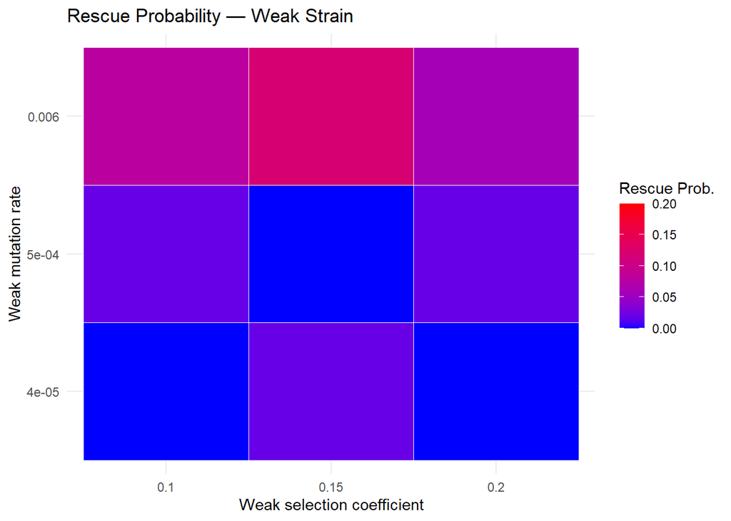

```r
ggplot(rescue_summary_weak,
       aes(x = factor(s_wm), y = factor(m_wm), fill = rescue_prob_weak)) +
  geom_tile(color = "white") +
  scale_fill_gradient(low = "blue", high = "red", limits = c(0, 0.2), oob = scales::squish) +
  labs(title = "Rescue Probability — Weak Strain",
       x = "Weak selection coefficient",
       y = "Weak mutation rate",
       fill = "Rescue Prob.") +
  theme_minimal()
```

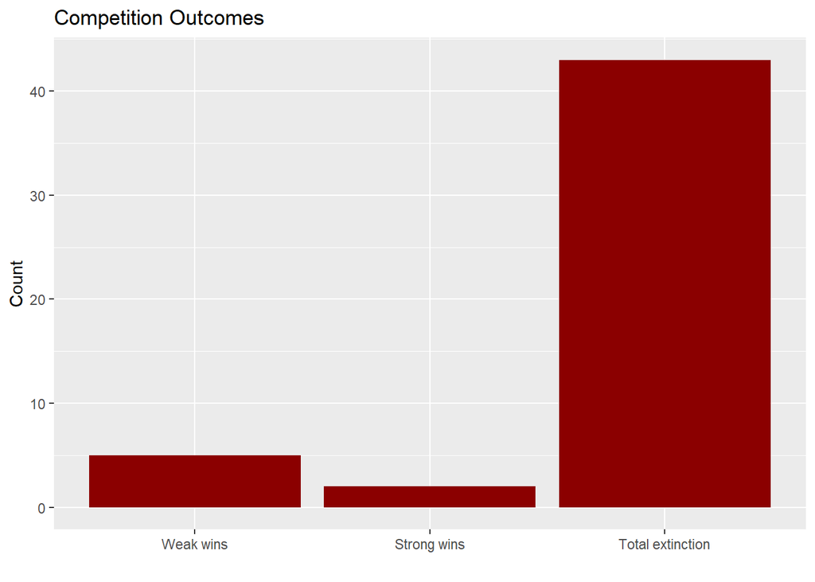

```r
# in this part, we want to compare how many times the strong strain "wins", how many times the weak strain "wins" and how often we get total extinction

#we create an empty data frame to store the results

competition_results <- data.frame(outcome = character())

#for each replicate it is determined
for (rep in 1:no_replicates) {

  one_run <- simulate_pop(
    init_wd, init_wb, init_sd, init_sb,
    decay_rate_wm, decay_rate_sm,
    s_wm, s_sm, m_rate_wm, m_rate_sm, max_gen
  )

  pop <- one_run$population

#for both strains, with tail, the last value is taken and if the value is bigger than 0 the strain is considered alive, indicated with weak_alive and strong_alive

  weak_alive   <- (tail(pop[, "wd"], 1) + tail(pop[, "wb"], 1)) > 0
  strong_alive <- (tail(pop[, "sd"], 1) + tail(pop[, "sb"], 1)) > 0

# with outcome, we asign the different cases to discriptions, if only weak is alive-->"weak wins", if only strong is alive--> "strong wins", if both are >0-->"both survive", if both go to extinction-->"total extinction"

 outcome <-
  if (weak_alive & !strong_alive) {
    "Weak wins"
  } else if (strong_alive & !weak_alive) {
    "Strong wins"
  } else if (strong_alive & weak_alive) {
    "Both survive"
  } else {
    "Total extinction"
  }


  competition_results <- rbind(
    competition_results,
    data.frame(outcome = outcome)
  )
}
competition_results$outcome <- factor(
  competition_results$outcome,
  levels = c("Weak wins", "Strong wins", "Total extinction", "Both survive")
)

# with ggplot, we create a barplot, which gives us the counts of the four different outcomes

ggplot(competition_results, aes(x = outcome)) +
  geom_bar(fill = "darkred") +
  labs(title = "Competition Outcomes",
       y = "Count", x = "")
```